# Week 4 Exercise

# Revisiting the GSE100687 dataset

For these exercises, we will re-visit the dataset from last weeks’ exercise; the published dataset with GEO accession number `GSE100687`. You will need to switch to the RStudio project that you created for this dataset.

**Exercise:** Create a new R markdown file and add the following code chunk to read the files from the GSE100687 dataset.

```r
library(readr)
library(dplyr)
library(tximport)
library(DESeq2)

sampleInfo <- read_tsv("meta_data/sampleInfo.txt")
tx2gene <- read_csv("tx2gene.csv",col_names = FALSE)
dirs <- list.files("salmon_output/")
quant_files <- list.files("salmon_output/",pattern="quant.sf",recursive = TRUE,full.names = TRUE)
names(quant_files) <- dirs
txi <- tximport(quant_files,
                type="salmon",
                tx2gene = tx2gene,
                ignoreTxVersion = TRUE)
```

```
reading in files with read_tsv
1 2 3 4 5 6
summarizing abundance
summarizing counts
summarizing length
```

```r
dds <- DESeqDataSetFromTximport(txi, colData = sampleInfo,
                                design = ~Treated)
```

```
using counts and average transcript lengths from tximport
```

```r
dds$CellLine <- as.factor(dds$CellLine)
```

We saw in the practical that the `plotCounts` function can provide a quick visualisation of counts across different sample groups

```
using 'avgTxLength' from assays(dds), correcting for library size
```

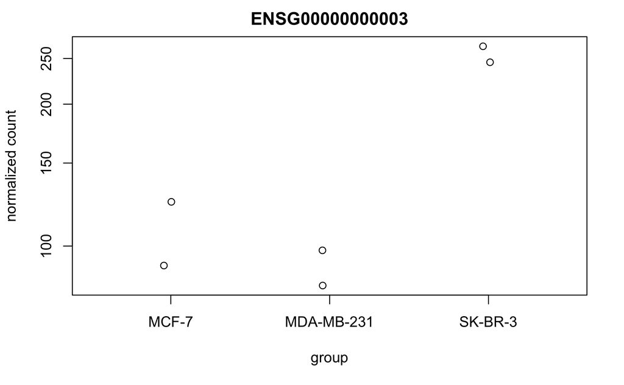

```r
plotCounts(dds, "ENSG00000000003", intgroup = "CellLine")
```

The plot doesn’t take full advantage of the `ggplot2` features that we have introduced recently. Fortunately, the authors have given the options for the data behind the plot to be retrieved.

```r
plotCounts(dds, "ENSG00000000003", intgroup = "CellLine",
           returnData = TRUE)
```

```
using 'avgTxLength' from assays(dds), correcting for library size
```

|  | count | CellLine |
| --- | --- | --- |
| SRR5788492 | 124.10677 | MCF-7 |
| SRR5788493 | 90.91849 | MCF-7 |
| SRR5788494 | 245.44462 | SK-BR-3 |
| SRR5788495 | 265.34821 | SK-BR-3 |
| SRR5788496 | 82.45899 | MDA-MB-231 |
| SRR5788497 | 97.91901 | MDA-MB-231 |

In order to make use of the *meta data* we have recorded for these samples, we need to join the table to the `sampleInfo` data frame we created earlier. The sample identifiers (`SRR`) appear as rownames, and not columns in the data frame itself. The `rownames_to_column` function can be used to create such a column. You can now join the sampleInfo and counts into a single data frame for plotting.

```r
plotCounts(dds, "ENSG00000000003", intgroup = "CellLine",
           returnData = TRUE) %>%
  tibble::rownames_to_column("SRR")
```

```
using 'avgTxLength' from assays(dds), correcting for library size
```

| SRR | count | CellLine |
| --- | --- | --- |
| SRR5788492 | 124.10677 | MCF-7 |
| SRR5788493 | 90.91849 | MCF-7 |
| SRR5788494 | 245.44462 | SK-BR-3 |
| SRR5788495 | 265.34821 | SK-BR-3 |
| SRR5788496 | 82.45899 | MDA-MB-231 |
| SRR5788497 | 97.91901 | MDA-MB-231 |

**Exercise**: Use one of the `_join` functions from `dplyr` to create a single data frame with the counts for this gene and the sample information. Visualise the counts using `ggplot2` and colour the counts according to whether the sample has been treated or not. See below for an example, but feel free to customise the plot.

The `left_join` function can be used to join the counts with the sample information. It is recommended to use `geom_jitter` rather than `geom_point` to distinguish the points more easily.

```
using 'avgTxLength' from assays(dds), correcting for library size
```

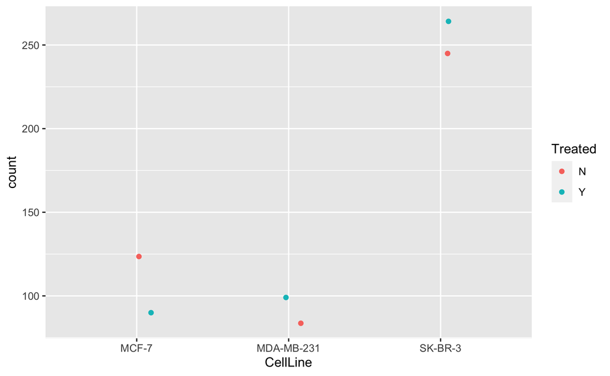

```r
library(ggplot2)
plotCounts(dds, "ENSG00000000003", intgroup = "CellLine",
           returnData = TRUE) %>%
  tibble::rownames_to_column("SRR") %>%
  left_join(sampleInfo) %>%
  ggplot(aes(x = CellLine, y = count,col=Treated)) + geom_jitter(width=0.1)
```

We saw in the practical that a PCA plot can help us decide what the main sources of variation in our dataset are - hopefully they should be the biological contrast that we are trying to compare. Before running a PCA, it is advisable to use a variance-stablising transformation.

```r
vsd <- vst(dds)
```

```
using 'avgTxLength' from assays(dds), correcting for library size
```

**Exercise**: Produce separate PCA plots using both `CellLine` and `Treated` as the `intgroup` argument. What do you notice? Do you think that the dataset will be effective at comparing Treated to Untreated samples?

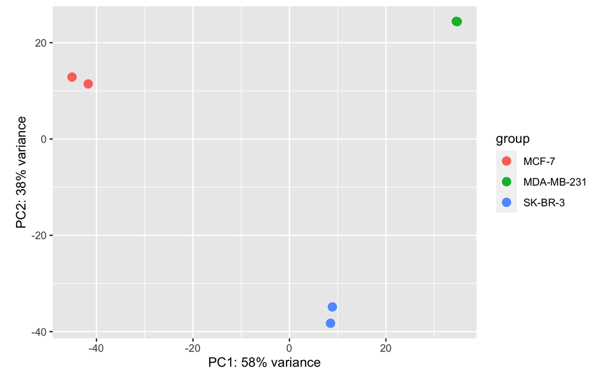

```r
plotPCA(vsd, intgroup="CellLine")
```

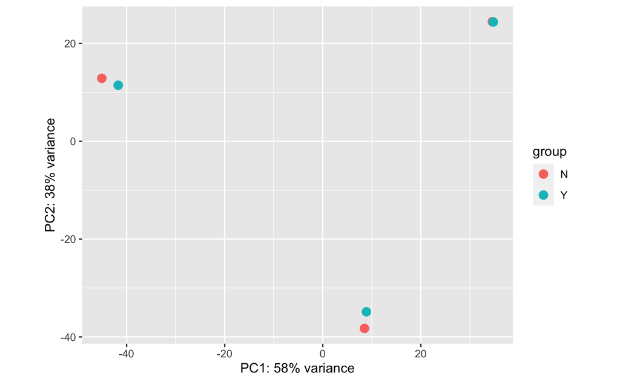

```r
plotPCA(vsd, intgroup="Treated")
```

The main difference in the dataset seems to be which CellLine the samples came from; rather than if they are treated with the drug.

**Exercise**: Proceed to use the `DESeq` function to identify genes that are differentially-expressed between treated and un-treated samples. Are you surprised by how many / how few genes have an adjusted p-value < 0.05?

The `DESeq` function will run the differential expression analysis between Treated and Untreated samples. A table of results can be obtained using the `results` function

```r
de <- DESeq(dds)
```

```
using 'avgTxLength' from assays(dds), correcting for library size
```

```r
results <- results(de,tidy=TRUE)
```

```r
filter(results, padj < 0.05)
```

| row | baseMean | log2FoldChange | lfcSE | stat | pvalue | padj |
| --- | --- | --- | --- | --- | --- | --- |
| ENSG00000100292 | 1159.27499 | 4.482068 | 0.8305457 | 5.396534 | 6.794044e-08 | 5.445766e-04 |
| ENSG00000120694 | 2909.81630 | 2.149027 | 0.4575749 | 4.696558 | 2.645815e-06 | 1.413836e-02 |
| ENSG00000132002 | 3879.27676 | 3.899865 | 0.6527996 | 5.974062 | 2.314177e-09 | 2.473238e-05 |
| ENSG00000173110 | 973.38602 | 8.897698 | 0.8257570 | 10.775201 | 4.507942e-27 | 1.445336e-22 |
| ENSG00000178381 | 298.64953 | 2.943140 | 0.6200975 | 4.746254 | 2.072185e-06 | 1.328768e-02 |
| ENSG00000204388 | 9901.02206 | 4.542487 | 0.6452919 | 7.039431 | 1.930267e-12 | 3.094411e-08 |
| ENSG00000225217 | 16.36777 | 7.460711 | 1.6174779 | 4.612558 | 3.977429e-06 | 1.821776e-02 |

Only 7 genes are identified with an adjusted p-value less than 0.05. This is not surprising as the main source of biological variation was the cell line.